# Probabilidad Aplicada

Santiago Longo y Rocco Fabro

2025-09-25

**Institución:** Instituto Nacional Superior del Profesorado Tecnico (INSPT)

**Profesora:** Marisa Casparian

# Índice

# 1.Introducción

En la vida moderna, las rutinas matutinas desempeñan un papel fundamental en el bienestar y la productividad de las personas. Desde los habitos alimenticios hasta el ejercicio físico y las horas de descanso, cada aspecto influye directamente en el rendimiento diario y el estado de animo general.

El presente informe tiene como propósito analizar diferentes componentes de la rutina matutina —como el tipo de desayuno, la cantidad de ejercicio o la duración del sueño— para determinar cómo se relacionan con el estado de animo y la productividad percibida por los individuos.

Para ello, se trabaja con el conjunto de datos **“Morning Routine Productivity Dataset”**, que contiene información de diversas personas sobre sus habitos matutinos, ejercicio físico, sueño, tipo de desayuno y productividad.

# 2. Objetivo

El objetivo principal de este estudio es **analizar la influencia de las rutinas matutinas en la productividad y el estado de animo de las personas**.  
A partir de los datos recolectados, se busca identificar patrones y correlaciones que permitan comprender qué habitos se asocian con un mejor rendimiento o bienestar general.

# 3. Analisis estadístico

## 3.1 Distribución de tipos de desayuno

Antes de analizar la productividad, se estudió la **distribución de los distintos tipos de desayuno** declarados por los participantes. Este grafico permite observar la preferencia general en las comidas matutinas, las cuales pueden tener un impacto directo en los niveles de energía y concentración.

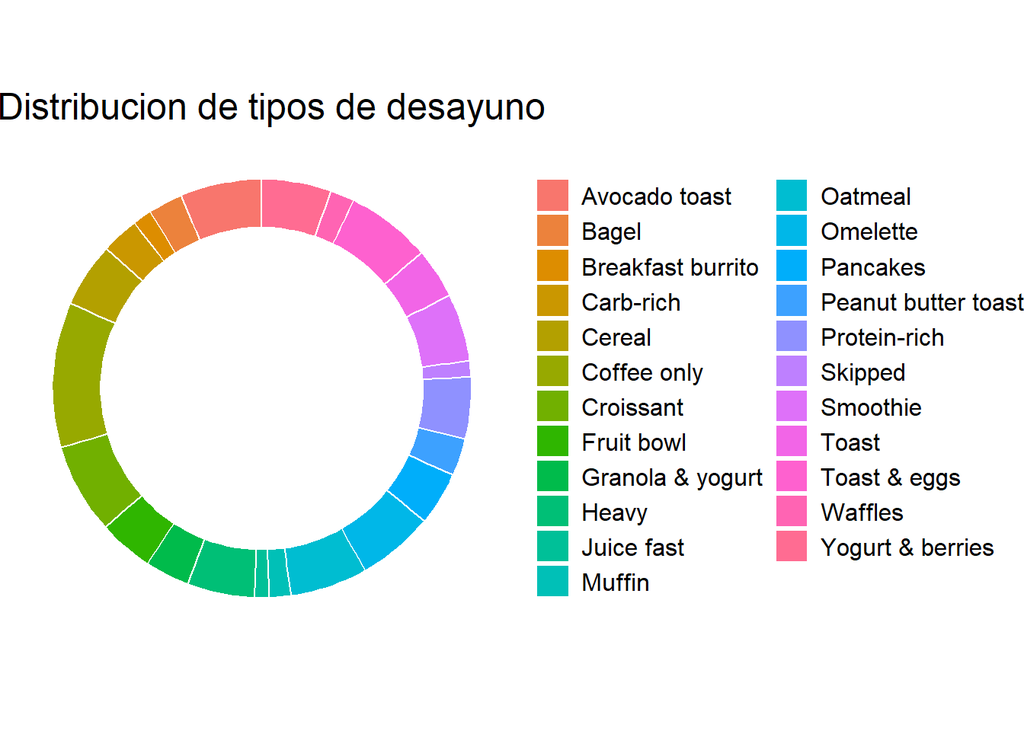

## 3.2 Actividades físicas mas frecuentes

El siguiente grafico muestra una nube de palabras con las actividades físicas mas mencionadas por los encuestados. Las palabras mas grandes representan los ejercicios mas frecuentes.

[interactive chart not shown]

### 3.2.1 Analisis:

Las actividades mas comunes tienden a ser aquellas de facil acceso y bajo costo, como caminar, correr o realizar yoga. La prevalencia de estas practicas sugiere que una gran parte de la población considera el ejercicio como un componente relevante de su rutina diaria. El tamaño de cada palabra ilustra la frecuencia, lo que ayuda a visualizar rapidamente cuales son las mas practicadas.

## 3.3 Productividad según alimentación

Se compararon los niveles productivos de los individuos con sus desayunos habituales.

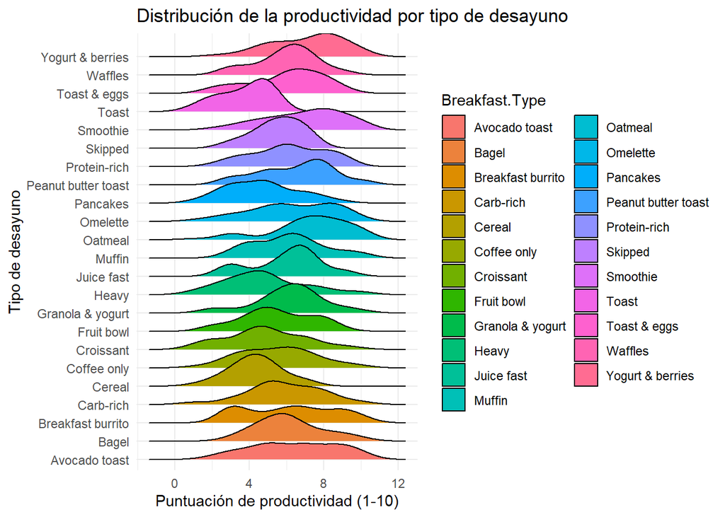

## 3.4 Ejercicio físico según estado de animo

El grafico de violín permite observar cómo varía la cantidad de ejercicio según el estado de animo reportado. Cada violín representa la distribución de minutos de ejercicio dentro de cada categoría emocional.

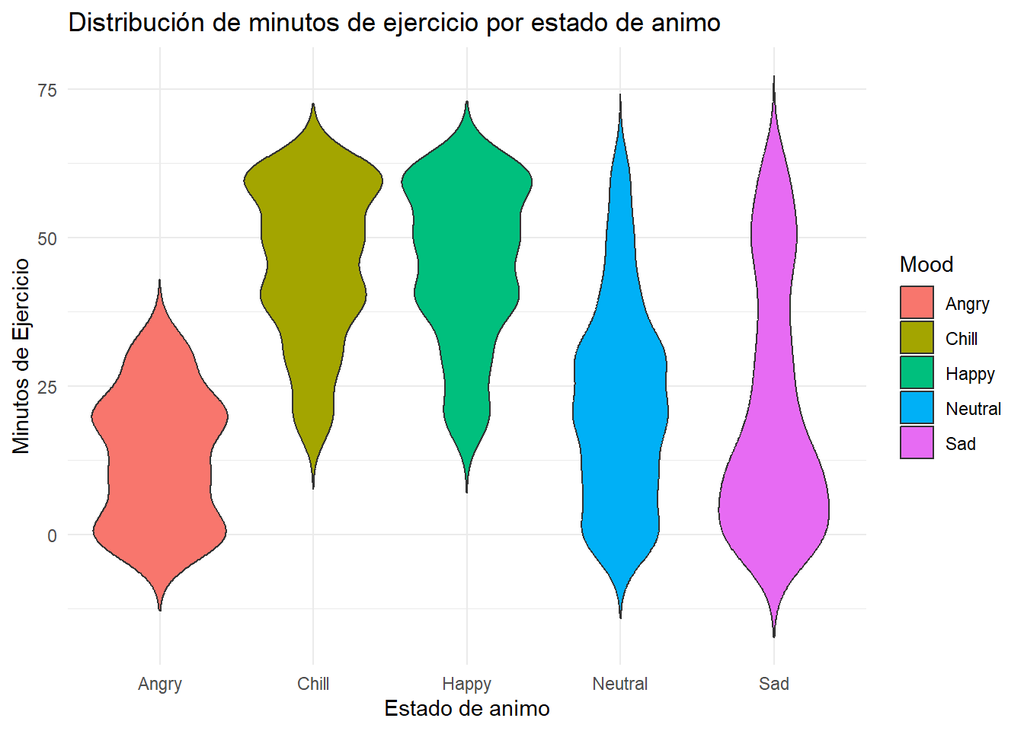

## 3.5 Productividad según horas de sueño

Finalmente, se analizó la relación entre las horas de sueño y el puntaje de productividad. Se graficó la productividad promedio en función de las horas dormidas, incluyendo una línea de tendencia lineal.

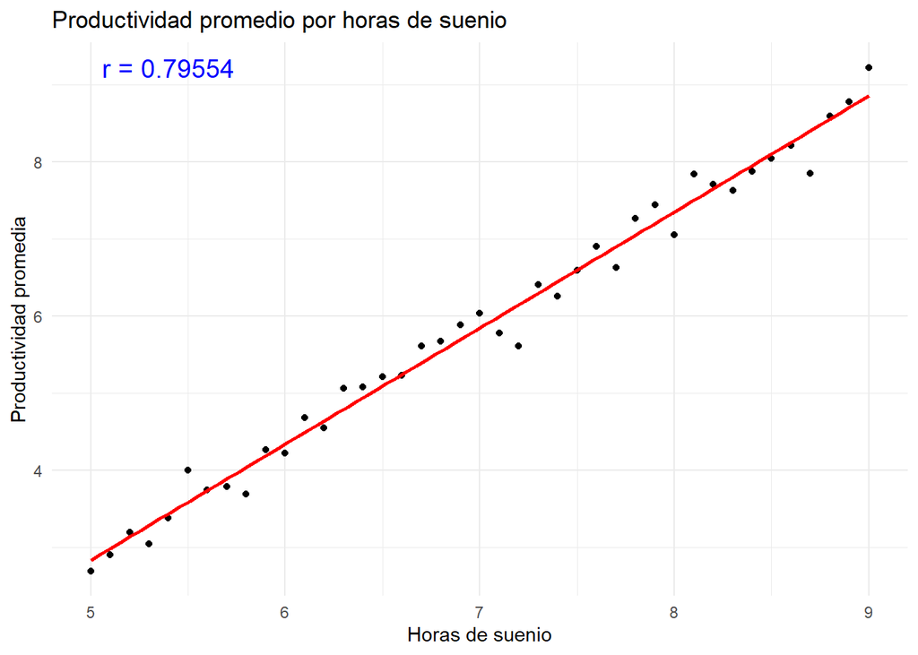

### 3.5.1 Analisis:

El coeficiente de correlación de Pearson (r = 0.795) indica una relación lineal positiva fuerte entre las horas de sueño y el nivel de productividad. Esto significa que, en general, a mayor cantidad de horas dormidas, mayor productividad promedio.

$$r = \frac{\sum (x_i - \bar{x})(y_i - \bar{y})}
{\sqrt{\sum (x_i - \bar{x})^2 \sum (y_i - \bar{y})^2}}$$

La línea de tendencia lineal del gráfico refuerza esta interpretación: muestra una pendiente ascendente que evidencia cómo el rendimiento tiende a mejorar conforme aumenta el descanso. Sin embargo, el valor de r no llega a 1, lo que sugiere que, aunque el sueño influye de manera considerable, no es el único factor determinante en la productividad.

# 4. Conclusión

Asimismo, el ejercicio físico aparece como un factor clave en el estado de ánimo, observándose que las personas con emociones positivas realizan más minutos de actividad física, lo que sugiere una relación bidireccional entre bienestar emocional y movimiento corporal.

Finalmente, la relación entre las horas de sueño y la productividad confirma una asociación lineal positiva fuerte: Esto indica que el descanso no solo favorece la concentración, sino que también potencia el impacto de otros hábitos saludables.

En conjunto, los resultados enfatizan que la productividad no depende de un único factor, sino de la interacción entre sueño, alimentación y ejercicio. Fomentar rutinas matutinas conscientes y sostenibles puede, por tanto, ser una estrategia efectiva para mejorar tanto el desempeño laboral o académico como el bienestar general de las personas.

# 5. Bibliografía

Los datos fueron obtenidos de la base:“Morning Routine Productivity Datase” de “https://www.kaggle.com/”